# Introduction

This report looks at information about colleges from the College Scorecard dataset. I am focusing on graduation rates, student debt, and earnings. The goal is to see what patterns appear in the data.

# Data Dictionary

| Variable | Meaning | Type |
| --- | --- | --- |
| `INSTNM` | Name of the college | Categorical |
| `STABBR` | State where the college is located | Categorical |
| `CONTROL` | Type of college ownership | Categorical |
| `UGDS` | Number of undergraduate students | Numerical |
| `C150_4` | Graduation rate for four-year colleges | Numerical |
| `DEBT_MDN` | Median student debt | Numerical |
| `MD_EARN_WNE_P10` | Median earnings ten years after students first enrolled | Numerical |

# Load the Data

The code below downloads the College Scorecard data and keeps only the seven variables listed above.

```r
# Download and open the dataset
url <- "https://ed-public-download.scorecard.network/downloads/Most-Recent-Cohorts-Institution_05192025.zip"
zip_file <- tempfile(fileext = ".zip")
download.file(url, zip_file, mode = "wb", quiet = TRUE)
folder <- tempfile()
dir.create(folder)
unzip(zip_file, exdir = folder)
csv_file <- list.files(folder, pattern = "\\.csv$", recursive = TRUE, full.names = TRUE)[1]

college_data <- read.csv(csv_file, stringsAsFactors = FALSE,
                         na.strings = c("", "NA", "PrivacySuppressed", "PS"))

# Keep the variables used in this report
college_data <- college_data[, c("INSTNM", "STABBR", "CONTROL", "UGDS",
                                 "C150_4", "DEBT_MDN", "MD_EARN_WNE_P10")]

# Make the number columns numeric
college_data$UGDS <- as.numeric(college_data$UGDS)
college_data$C150_4 <- as.numeric(college_data$C150_4)
college_data$DEBT_MDN <- as.numeric(college_data$DEBT_MDN)
college_data$MD_EARN_WNE_P10 <- as.numeric(college_data$MD_EARN_WNE_P10)
```

# Dataset Size

```r
dim(college_data)
```

```
## [1] 6429    7
```

The first number is the number of colleges (rows). The second number is the number of variables (columns) used in this report.

# Summary Statistics

## Numerical Variables

This table gives basic summary information for the numerical variables. It includes the minimum, maximum, median, and other values.

```r
summary(college_data[, c("UGDS", "C150_4", "DEBT_MDN", "MD_EARN_WNE_P10")])
```

```
##       UGDS            C150_4          DEBT_MDN     MD_EARN_WNE_P10
##  Min.   :     0   Min.   :0.0000   Min.   : 1932   Min.   :  8579
##  1st Qu.:   116   1st Qu.:0.3720   1st Qu.: 7000   1st Qu.: 31830
##  Median :   494   Median :0.5252   Median : 9500   Median : 40568
##  Mean   :  2488   Mean   :0.5202   Mean   :11269   Mean   : 43508
##  3rd Qu.:  2074   3rd Qu.:0.6711   3rd Qu.:15000   3rd Qu.: 51994
##  Max.   :156755   Max.   :1.0000   Max.   :38980   Max.   :143372
##  NAs    :773      NAs    :4157     NAs    :1146    NAs    :1149
```

The summary helps show how much colleges differ in enrollment, graduation rates, debt, and earnings.

## Histograms

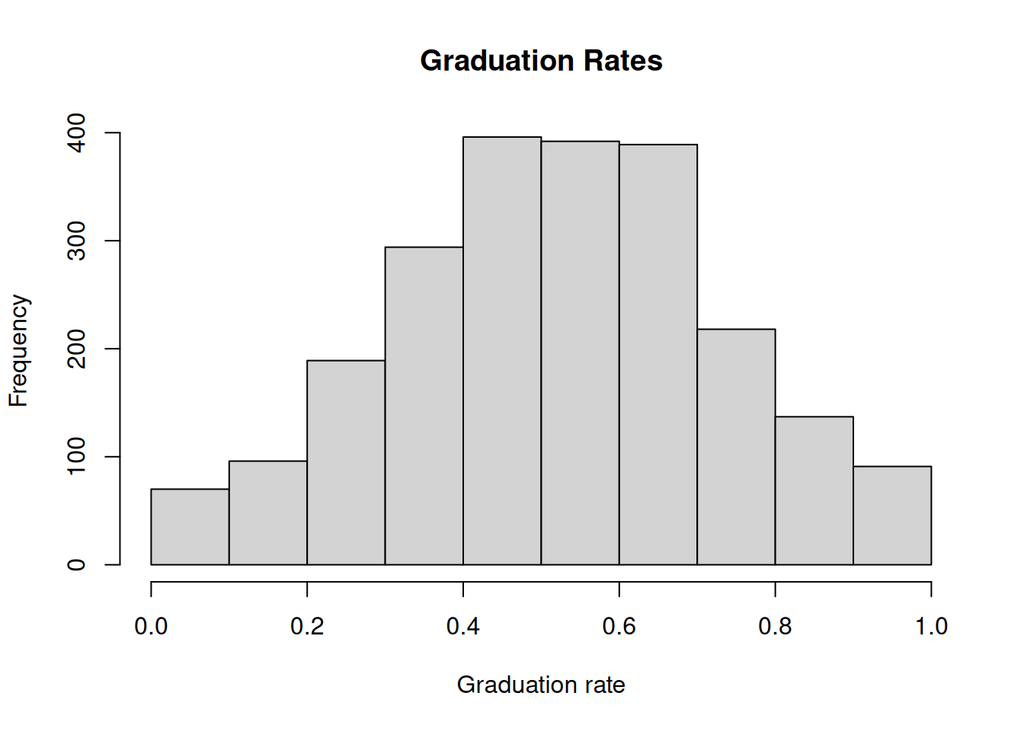

```r
hist(na.omit(college_data$C150_4), main = "Graduation Rates", xlab = "Graduation rate")
```

This histogram shows how graduation rates are spread across the colleges in the dataset.

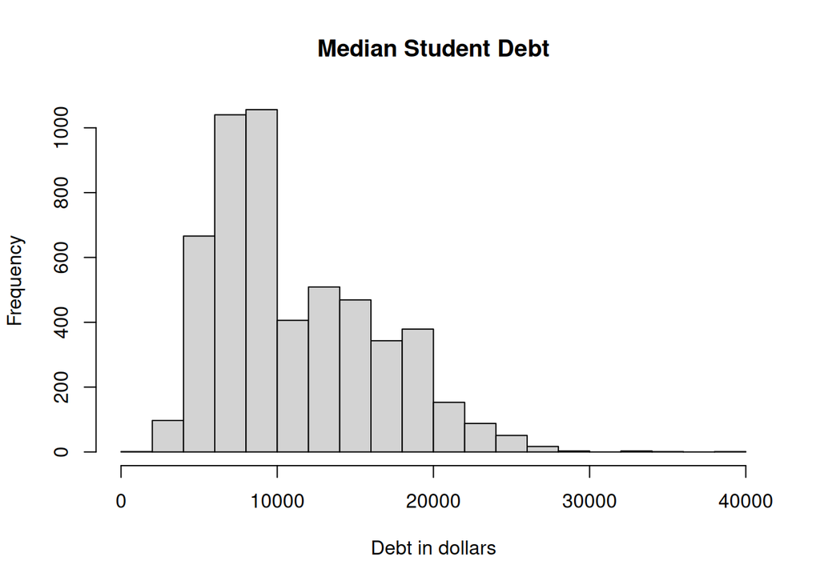

```r
hist(na.omit(college_data$DEBT_MDN), main = "Median Student Debt", xlab = "Debt in dollars")
```

This histogram shows how reported student debt differs between colleges.

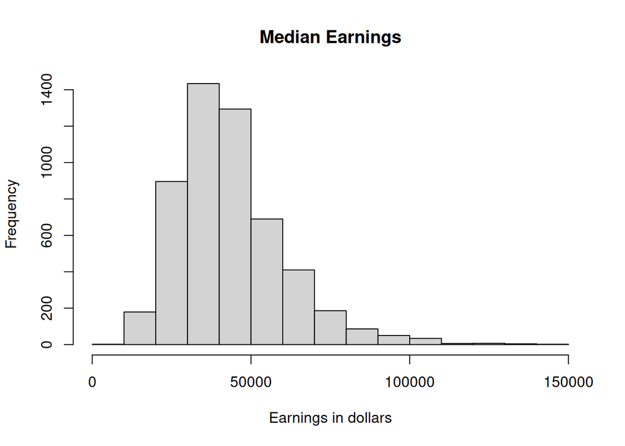

```r
hist(na.omit(college_data$MD_EARN_WNE_P10), main = "Median Earnings", xlab = "Earnings in dollars")
```

This histogram shows the reported earnings ten years after students first enrolled. It does not mean every graduate earns this amount.

## Categorical Variable

```r
table(college_data$CONTROL, useNA = "ifany")
```

```
##
##    1    2    3
## 2056 1953 2420
```

This table counts how many colleges are in each ownership category. The values are codes used by the original dataset.

# Data Cleanliness

This table shows how many missing values appear in each variable.

```r
colSums(is.na(college_data))
```

```
##          INSTNM          STABBR         CONTROL            UGDS          C150_4
##               0               0               0             773            4157
##        DEBT_MDN MD_EARN_WNE_P10
##            1146            1149
```

Some information is missing because not every college reports every measure. Some values may also be suppressed to protect student privacy. Missing values are not the same as zero.

The code below checks for duplicate rows.

```r
sum(duplicated(college_data))
```

```
## [1] 0
```

This gives the number of duplicate rows in the selected data. No rows are removed in this report.

# Discussion

The College Scorecard dataset has a lot of information about colleges. For this report, I focused on a small number of variables related to graduation rates, student debt, and earnings. The summary statistics and histograms make it easier to see how colleges differ in these areas. They also give me a starting point for looking at possible relationships between the variables.

There are some limits to this data. Some values are missing or hidden, and the earnings measure is based on ten years after students first enrolled, not necessarily ten years after they graduated. The dataset also describes colleges overall instead of individual students. For the next part of the project, I plan to compare graduation rates with debt and earnings using simple scatterplots. This could help show whether these variables are related, but it would not prove that one causes another.

# References

U.S. Department of Education. *College Scorecard Dataset*. Data.gov. https://catalog.data.gov/dataset/college-scorecard